# Tugas Pertemuan 4

Rahmandani Bardianto G1401231029

# Import

```r
data_aqi = read.csv("C:/Users/PC/Downloads/NewDelhi_Air_quality.csv")
head(data_aqi)
```

```
##   X  AQI       CO      datetime        no2       o3      pm10     pm25
## 1 0 30.2 198.6027 2022-10-21:18 0.04685717 55.78995 10.486722 5.637410
## 2 1 28.2 197.6013 2022-10-21:19 0.04645554 54.93164 10.719325 4.618169
## 3 2 26.6 198.6027 2022-10-21:20 0.04685717 54.64554 11.155578 3.520902
## 4 3 25.0 201.9405 2022-10-21:21 0.04819594 55.07469 11.116206 2.225919
## 5 4 26.0 205.2784 2022-10-21:22 0.04886533 55.78995 10.405250 1.979471
## 6 5 26.0 208.6163 2022-10-21:23 0.05020411 56.50520  9.402518 1.792677
##         so2     timestamp_local       timestamp_utc         ts
## 1 0.3874302 2022-10-21T23:00:00 2022-10-21T18:00:00 1666375200
## 2 0.4097819 2022-10-22T00:00:00 2022-10-21T19:00:00 1666378800
## 3 0.4023313 2022-10-22T01:00:00 2022-10-21T20:00:00 1666382400
## 4 0.3762543 2022-10-22T02:00:00 2022-10-21T21:00:00 1666386000
## 5 0.3390014 2022-10-22T03:00:00 2022-10-21T22:00:00 1666389600
## 6 0.3129244 2022-10-22T04:00:00 2022-10-21T23:00:00 1666393200
```

```r
library(dLagM)
library(dynlm)
library(MLmetrics)
library(lmtest)
library(car)
str(data_aqi)
```

```
## 'data.frame':    72 obs. of  12 variables:
##  $ X              : int  0 1 2 3 4 5 6 7 8 9 ...
##  $ AQI            : num  30.2 28.2 26.6 25 26 26 26 24 23 24 ...
##  $ CO             : num  199 198 199 202 205 ...
##  $ datetime       : chr  "2022-10-21:18" "2022-10-21:19" "2022-10-21:20" "2022-10-21:21" ...
##  $ no2            : num  0.0469 0.0465 0.0469 0.0482 0.0489 ...
##  $ o3             : num  55.8 54.9 54.6 55.1 55.8 ...
##  $ pm10           : num  10.5 10.7 11.2 11.1 10.4 ...
##  $ pm25           : num  5.64 4.62 3.52 2.23 1.98 ...
##  $ so2            : num  0.387 0.41 0.402 0.376 0.339 ...
##  $ timestamp_local: chr  "2022-10-21T23:00:00" "2022-10-22T00:00:00" "2022-10-22T01:00:00" "2022-10-22T02:00:00" ...
##  $ timestamp_utc  : chr  "2022-10-21T18:00:00" "2022-10-21T19:00:00" "2022-10-21T20:00:00" "2022-10-21T21:00:00" ...
##  $ ts             : int  1666375200 1666378800 1666382400 1666386000 1666389600 1666393200 1666396800 1666400400 1666404000 1666407600 ...
```

# Eksplorasi

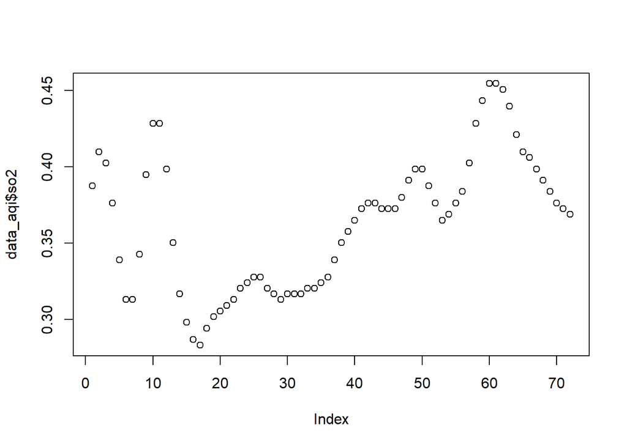

```r
#Eksplorasi


plot(data_aqi$so2)
```

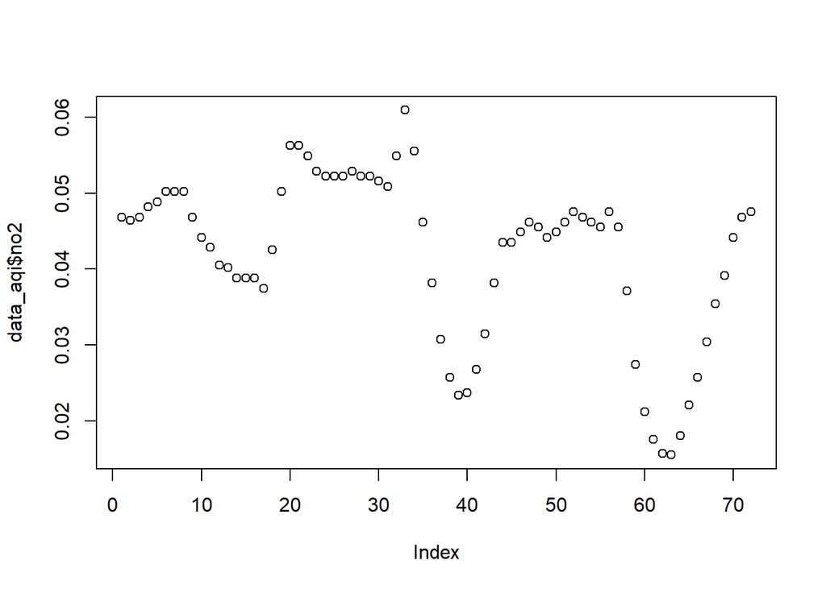

```r
plot(data_aqi$no2)
```

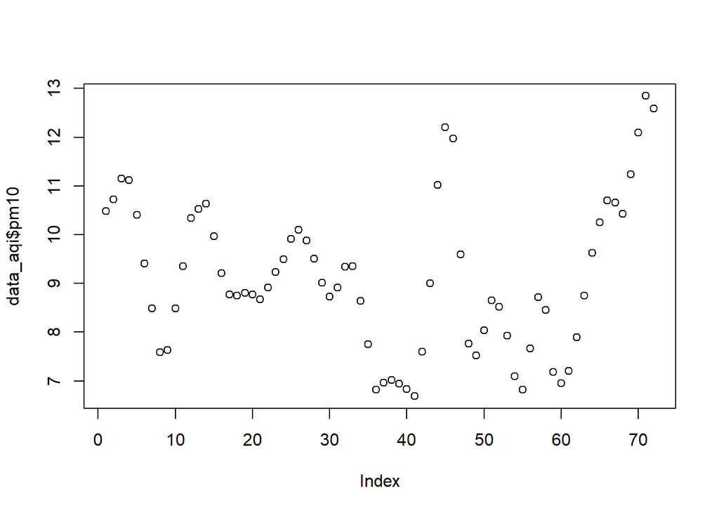

```r
plot(data_aqi$pm10)
```

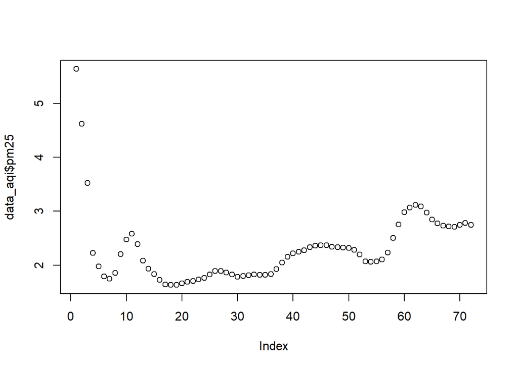

```r
plot(data_aqi$pm25)
```

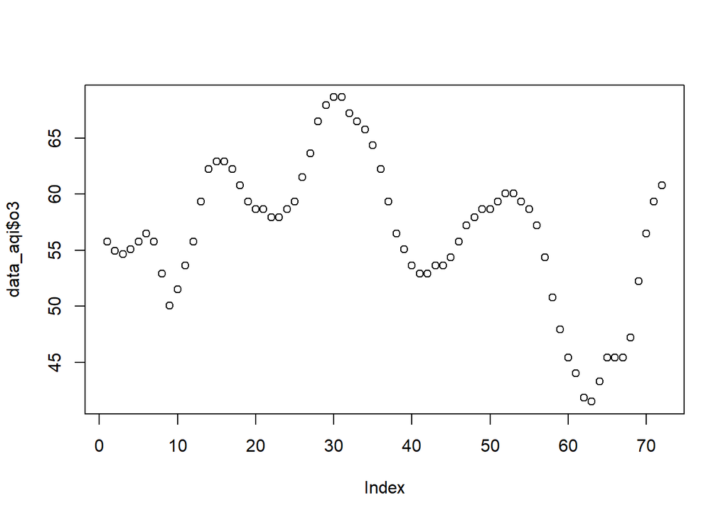

```r
plot(data_aqi$o3)
```

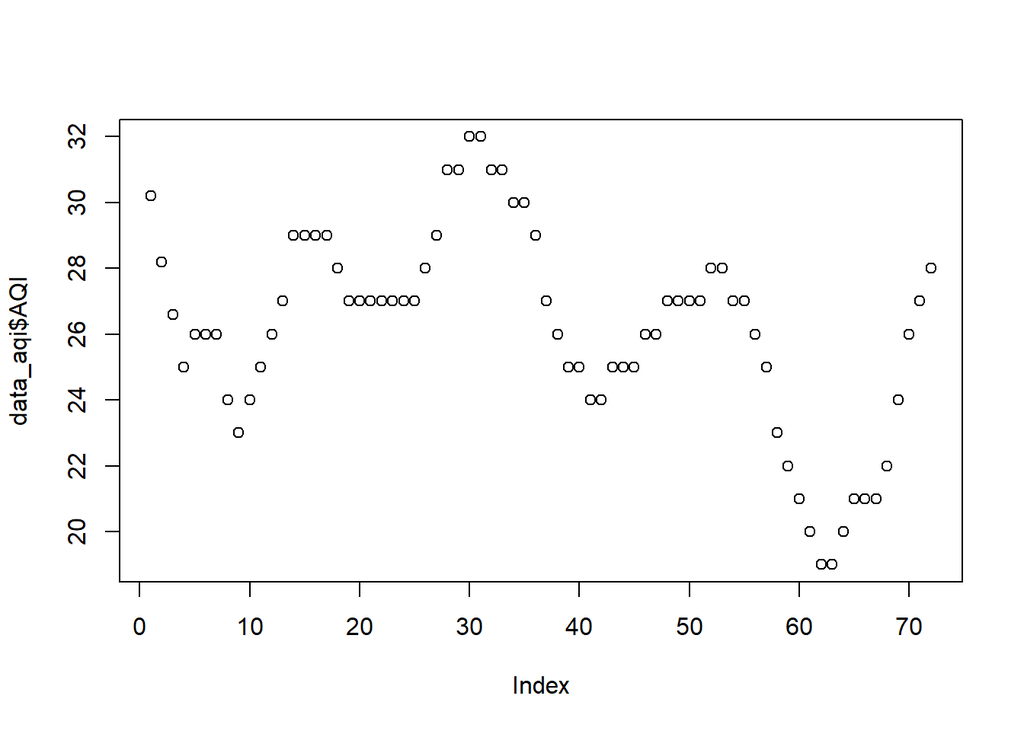

```r
plot(data_aqi$AQI)
```

## Eksplorasi o3 dan AQI setiap 8 jam

```r
#Eksplorasi o3 dan AQI setiap 8 jam

#Korelasi
cor.test(data_aqi$AQI, data_aqi$o3,  method = "pearson")
```

```
##
##  Pearson's product-moment correlation
##
## data:  data_aqi$AQI and data_aqi$o3
## t = 35.685, df = 70, p-value < 2.2e-16
## alternative hypothesis: true correlation is not equal to 0
## 95 percent confidence interval:
##  0.9580123 0.9834485
## sample estimates:
##      cor
## 0.973599
```

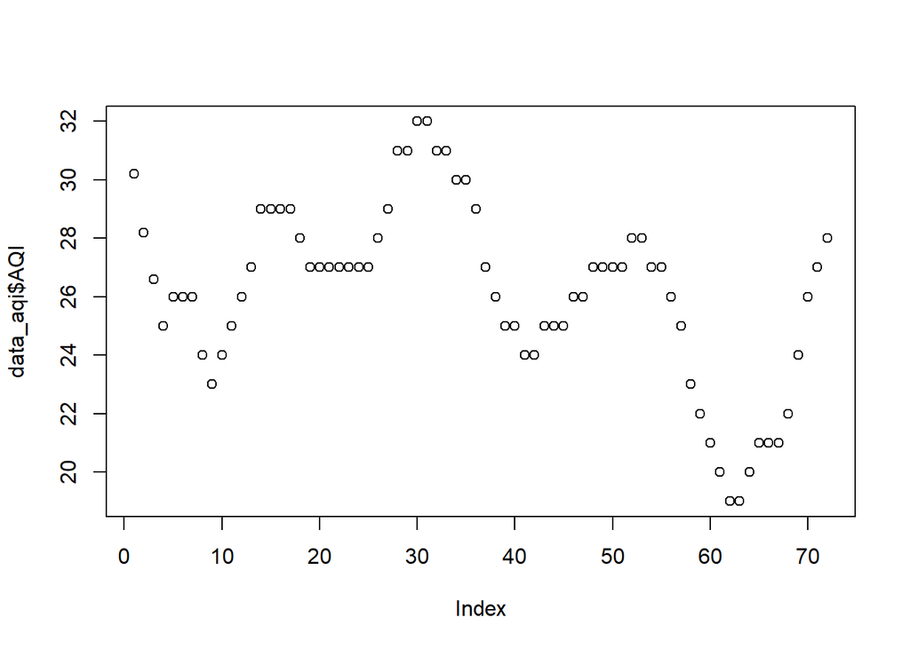

```r
#Plot AQI
#Membagi menjadi setiap 8 jam
plot(data_aqi$AQI)
```

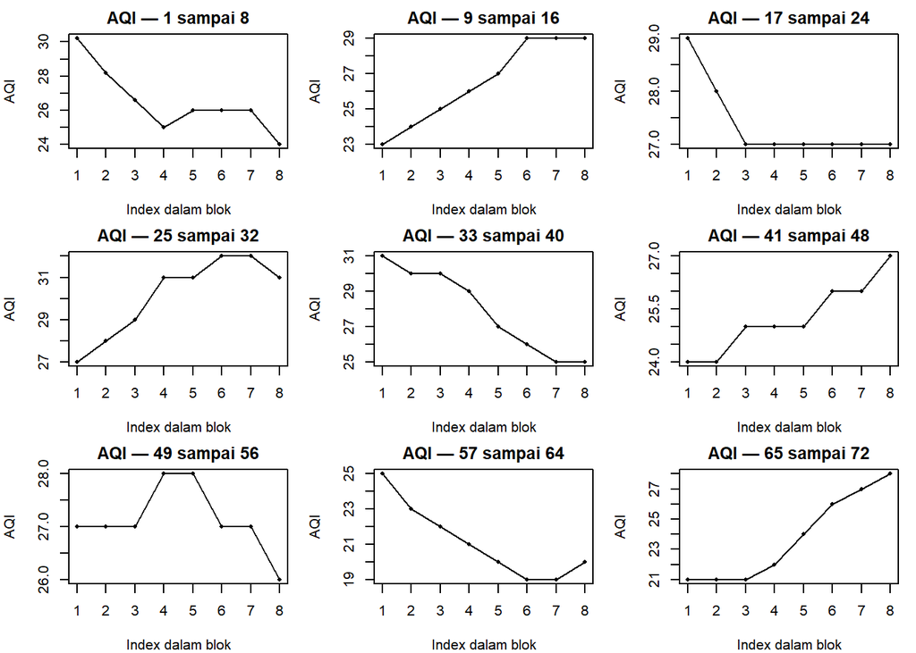

```r
par(mfrow = c(3,3), mar = c(4,4,2,1))
for (i in seq(1, 72, by = 8)) {
  idx_akhir = min(i + 7, nrow(data_aqi))
  plot(data_aqi$AQI[i:idx_akhir], type = "l",
       xlab = "Index dalam blok", ylab = "AQI",
       main = paste("AQI —", i, "sampai", idx_akhir))
  points(data_aqi$AQI[i:idx_akhir], pch = 16, cex = 0.6)
}
```

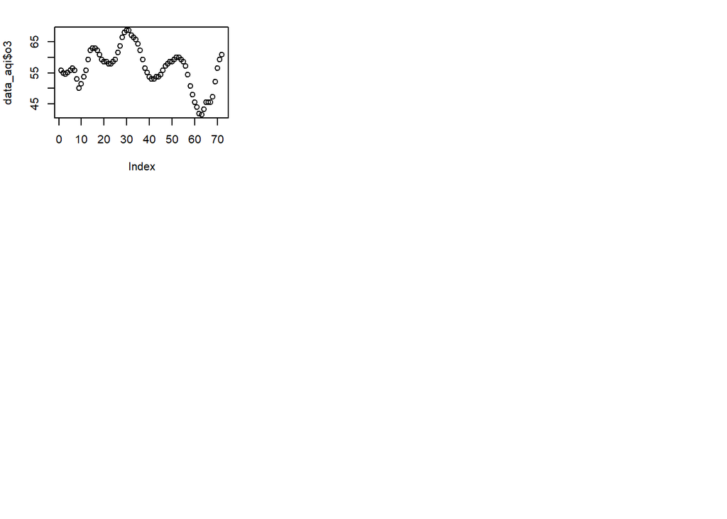

```r
#Plot o3
plot(data_aqi$o3)
par(mfrow = c(3,3), mar = c(4,4,2,1))
```

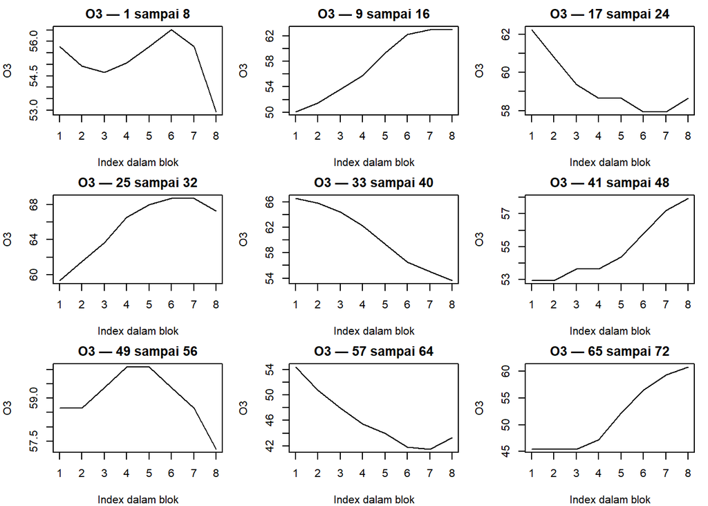

```r
for (i in seq(1, 72, by = 8)) {
  idx_akhir = min(i + 7, nrow(data_aqi))
  plot(data_aqi$o3[i:idx_akhir], type = "l",
       xlab = "Index dalam blok", ylab = "O3",
       main = paste("O3 —", i, "sampai", idx_akhir))
  points(data_aqi$O3[i:idx_akhir], pch = 16, cex = 0.6)
}
```

# Pemilihan variabel penjelas (X) Berdasarkan hasil eksplorasi, didapatkan bahwa nilai ozone (o3) memiliki pola yang paling menyerupai pola dari AQI. O₃ di permukaan bumi adalah polutan sekunder yang terbentuk dari reaksi kompleks antara NOx dan VOC di bawah sinar matahari. Tidak seperti PM₂.₅ yang lebih merata, ozon bersifat hiper-lokal: beda konsentrasi antar stasiun dalam satu kota bisa lebih dari 100 µg/m³. Oleh karena itu, regulasi global (misalnya USEPA) merekomendasikan AQI dihitung dari stasiun dengan konsentrasi O₃ tertinggi, bukan rata-rata (Roychowdhury 2021)